# Online News Popularity(Mashable)

The Online News Popularity dataset was published by Mashable, which is a online platform for media and entertainment news. The data set contains details about the various news articles published on the website such as their category, url, date published and the number of times it was shared.

The following are our proposed research questions:

Which is the best day to release a new article? Are people less likely to read about business on the weekend?

How does text and image quantity in articles relate to the number of shares

Does the rate of sharing positive and negative news vary with the time of the year?

#### **Q1.Which is the best day to release a new article? Are people less likely to read about business on the weekend?**

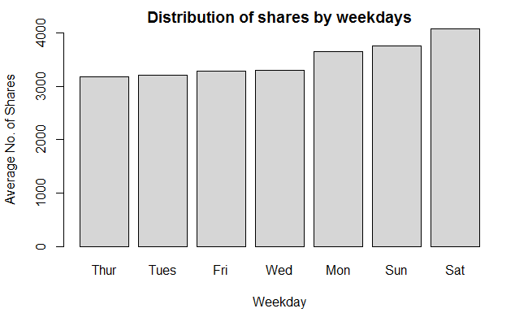

```r
OnlineNewsPopularity=read.csv("OnlineNewsPopularity-R.csv")
Q1.1_Data <- subset(OnlineNewsPopularity, select = c(weekday_is_monday, weekday_is_tuesday, weekday_is_wednesday, weekday_is_thursday, weekday_is_friday, weekday_is_saturday, weekday_is_sunday, is_weekend, shares))
# get average no. of shares Monday ~ Sunday
m1 <- mean(subset(OnlineNewsPopularity, weekday_is_monday == 1, select = shares)$shares)
m2 <- mean(subset(OnlineNewsPopularity, weekday_is_tuesday == 1, select = shares)$shares)
m3 <- mean(subset(OnlineNewsPopularity, weekday_is_wednesday == 1, select = shares)$shares)
m4 <- mean(subset(OnlineNewsPopularity, weekday_is_thursday == 1, select = shares)$shares)
m5 <- mean(subset(OnlineNewsPopularity, weekday_is_friday == 1, select = shares)$shares)
m6 <- mean(subset(OnlineNewsPopularity, weekday_is_saturday == 1, select = shares)$shares)
m7 <- mean(subset(OnlineNewsPopularity, weekday_is_sunday == 1, select = shares)$shares)
weekday_mean <- c(m1, m2, m3, m4, m5, m6, m7)
weekday_name <- c("Monday", "Tuesday", "Wednesday", "Thursday", "Friday", "Saturday", "Sunday")
weekday_dc <- data.frame(weekday_name, weekday_mean) # put means and weekday labels in a dataframe
weekday_dc <- weekday_dc[order(weekday_dc$weekday_mean),] # sort by means, ascending
weekday_mean <- sort(weekday_mean) # sort means
# barplot
barplot(weekday_mean,
        main = "Distribution of shares by weekdays",
        xlab = "Weekday",
        ylab = "Average No. of Shares",
        ylim = c(0,4000),
        col = colors()[237],
        names.arg = c("Thur", "Tues", "Fri", "Wed", "Mon", "Sun", "Sat")
)
```

**Description:**The plot above shows the how the average number of shares vary with the day of the week. The plot is sorted in ascending order from left to right, so we can say that the average number of shares on Saturday is highest amongst all days. Saturday is closely followed by Sunday and Monday. We can conclude that overall, average number of shares on a weekend is higher than on the weekdays.

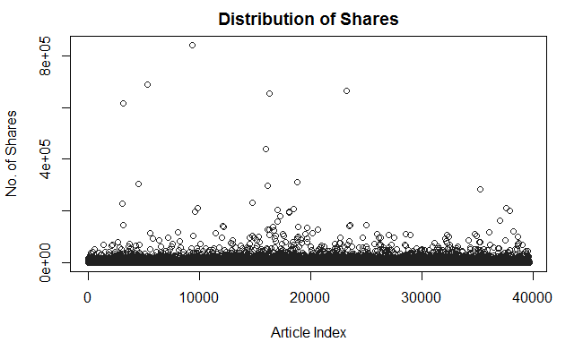

```r
plot(Q1.1_Data$shares,
     main = "Distribution of Shares",
     xlab = "Article Index",
     ylab = "No. of Shares",
     col = colors()[166])
```

**Description:**The Plot above shows the distribution of shares of all articles in our dataset. Each plot represents the its index and number of shares. Although it doesn’t directly answer any of our questions, it gives us an overall understanding of the magnitude of our dataset. We can see clearly that the majority of articles published have roughly below 4,000 shares, and a few articles reach more than 600,000 shares

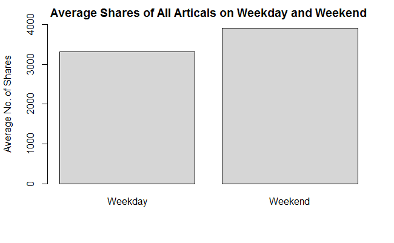

```r
## Barplot, average no. of shares weekday vs. weekend
# get average no. shares weekday vs. weekend
m_wd_all <- mean(subset(OnlineNewsPopularity, is_weekend == 0, select = shares)$shares)
m_we_all <- mean(subset(OnlineNewsPopularity, is_weekend == 1, select = shares)$shares)
m_wd_we_all <- c(m_wd_all, m_we_all)
# barplot
barplot(m_wd_we_all,
        main = "Average Shares of All Articals on Weekday and Weekend",
        ylab = "Average No. of Shares",
        ylim = c(0,4000),
        col = colors()[237],
        names.arg = c("Weekday", "Weekend"))
```

**Description:**This plot shows how does the sharing of all articles vary with the time of the week. The plot shows that in general, articles are shared more times on weekend than weekdays, with roughly 600 in difference.

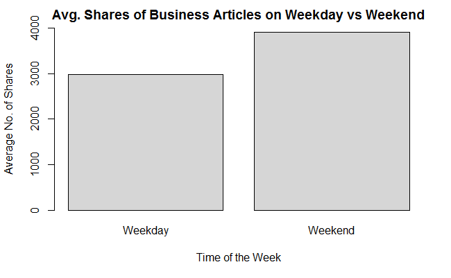

```r
## Average no. of shares of business articles, weekday vs. weekend
Q1.2.1_Data <- subset(OnlineNewsPopularity, data_channel_is_bus == 1, select = c(weekday_is_monday, weekday_is_tuesday, weekday_is_wednesday, weekday_is_thursday, weekday_is_friday, weekday_is_saturday, weekday_is_sunday, is_weekend, shares))
# get average no. of shares on weekday and weekend
m_wd <- mean(subset(Q1.2.1_Data, is_weekend == 0, select = shares)$shares)
m_we <- mean(subset(Q1.2.1_Data, is_weekend == 1, select = shares)$shares)
m_bus_wd_we <- c(m_wd, m_we)
# barplot
barplot(m_bus_wd_we,
        main = "Avg. Shares of Business Articles on Weekday vs Weekend",
        ylab = "Average No. of Shares",
        xlab = "Time of the Week",
        ylim = c(0,4000),
        col = colors()[237],
        names.arg = c("Weekday", "Weekend"))
```

**Description:**This plot shows how does the sharing of articles under the topic “Business” vary with the time of the week. This is an interesting result as we usually expect articles about business to be shared more on the weekdays than on the weekends. However, the plot clearly shows that the business articles fare better on a weekend with a difference of about 1000 in the average number of shares.

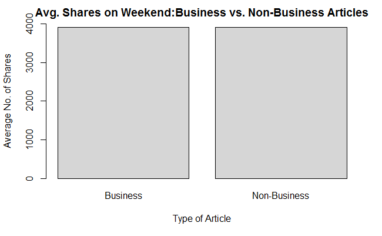

```r
## On weekend, average no. of shares: business articles vs. non-business articles
Q1.2.2_Data <- subset(OnlineNewsPopularity, is_weekend == 1, select = c(data_channel_is_bus, shares))
# get average no. of shares of business and non-business articles
m_wd_b <- mean(subset(Q1.2.2_Data, data_channel_is_bus == 1, select = shares)$shares)
m_wd_nb <- mean(subset(Q1.2.2_Data, data_channel_is_bus == 0, select = shares)$shares)
m_wd_b_nb <- c(m_wd_b, m_wd_nb)
# bar plot
barplot(m_wd_b_nb,
        main = "Avg. Shares on Weekend:Business vs. Non-Business Articles",
        ylab = "Average No. of Shares",
        xlab = "Type of Article",
        ylim = c(0,4000),
        col = colors()[237],
        names.arg = c("Business", "Non-Business"))
```

#### **Q2. How does text and image quantity in articles relate to the number of shares?**

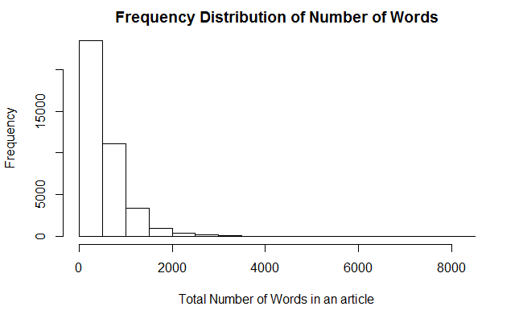

```r
hist(number_of_words, xlab = "Total Number of Words in an article", main = "Frequency Distribution of Number of Words")
```

**Description:Frequency Distribution of the total number of words in an article. This shows that histogram is right skewed**

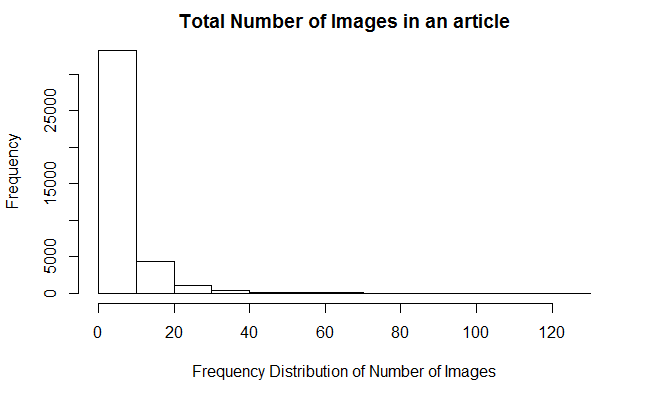

```r
hist(num_images, main = "Total Number of Images in an article", xlab = "Frequency Distribution of Number of Images")
```

**Description:Frequency Distribution of the total number of images in an article. This shows that histogram is right skewed**

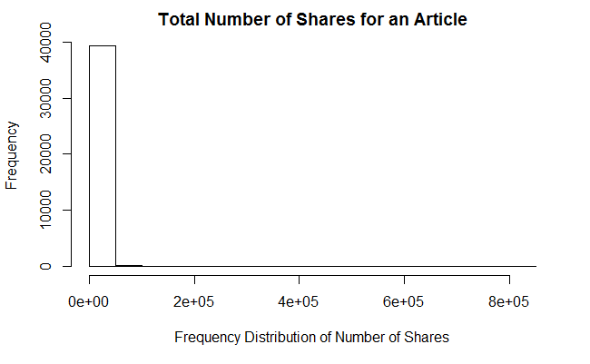

```r
hist(shares, main = "Total Number of Shares for an Article", xlab = "Frequency Distribution of Number of Shares")
```

**Description:Frequency Distribution of the total number of shares in an article. This shows that histogram is right skewed**

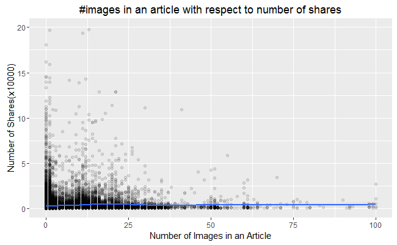

```r
library(ggplot2)
library(xkcd)
library(extrafont)
#Since the number of shares is very large, we have divided it by 10000 and saved it as new column called 'numshare'
Q2_data$numshare<- shares/10000
#Distribution of number of images and number or words, respectively, in an article with respect to number of shares (x10000) of that article
#The parameter alpha is used to show the density of the articles at that point
#The line is made to view the trend of the data since we have a lot of data points.
qplot(num_images, numshare,data = Q2_data, xlab = "Number of Images in an Article", ylab = "Number of Shares(x10000)", main = "#images in an article with respect to number of shares", xlim = c(0, 100), ylim = c(0,20), alpha = I(1/10), geom = c("point", "smooth"),width = 100)
```

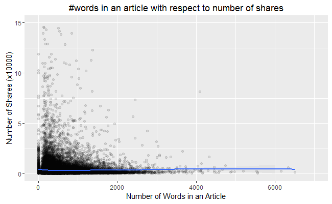

```r
qplot(number_of_words, numshare, data = Q2_data, xlab = "Number of Words in an Article", ylab = "Number of Shares (x10000)", main = "#words in an article with respect to number of shares", xlim = c(0, 7000), ylim = c(0,15), alpha = I(1/10), geom = c("point", "smooth"))
```

**Description:**This graph the trend of the number of images in an article along with the number of shares of that article. We can interpret from the trend line that there is a slight relation between number of images and the number of shares. The articles with images in the range of 10-30 have a higher number of shares. The second graph shows the trend of the number of words in an article along with the number of shares of that article.We can interpret from the trend line that there is no specific relationship between the number of shares and the number of words.

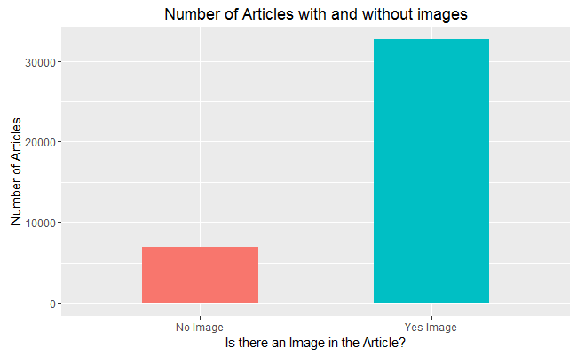

```r
#This bar graph shows the number of articles with an image and the number of articles without an image respectively
ggplot(data = Q2_data, aes(x = image_there)) +
  geom_bar(aes(fill = image_there), stat="count", width = 0.5)+
  xlab("Is there an Image in the Article?")+ ylab("Number of Articles") +
  ggtitle("Number of Articles with and without images") +
  theme(legend.position = "none")
```

**Description:**This bar graph shows the number of articles with an image and the number of articles without an image respectively

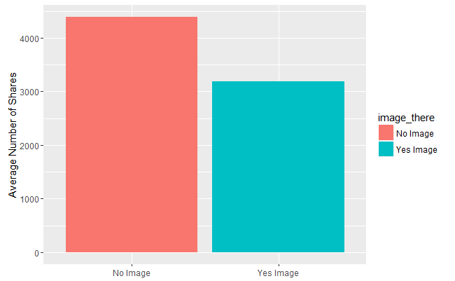

```r
#This plot shows the average number of shares for articles with an image and without an image respectively
res <- aggregate(shares ~ image_there, data = Q2_data, FUN = mean)
ggplot(res, aes(x = image_there, y = shares)) +
  geom_bar(aes(fill = image_there), stat = "identity") +
  xlab(NULL) + ylab("Average Number of Shares")
```

**Description:**This plot shows the average number of shares for articles with an image and without an image respectively. We can interpret from this graph that the average number of shares of an article with NO IMAGE is higher (4395.779) and with an IMAGE is lower (3181.344)

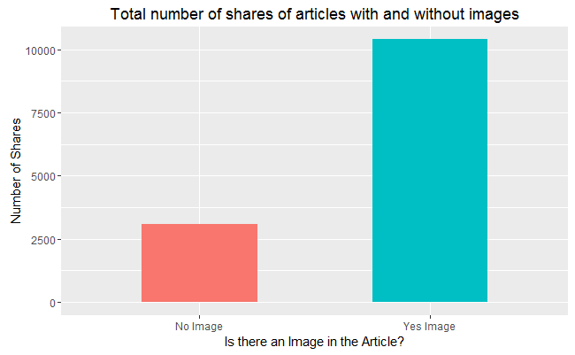

```r
#This plot shows the total number of shares of articles with an image and without and image respectively
ggplot(data = Q2_data, aes(x = image_there, y = numshare)) +
  geom_bar(aes(fill = image_there),stat="identity", width = 0.5) +
  xlab("Is there an Image in the Article?")+ ylab("Number of Shares") +
  ggtitle("Total number of shares of articles with and without images")+
  theme(legend.position = "none")
```

**Description:**This plot shows the total number of shares of articles with an image and without and image respectively. We can interpret from this graph that the total number of shares of all articles with NO IMAGES is much lower as compared to the articles with IMAGES

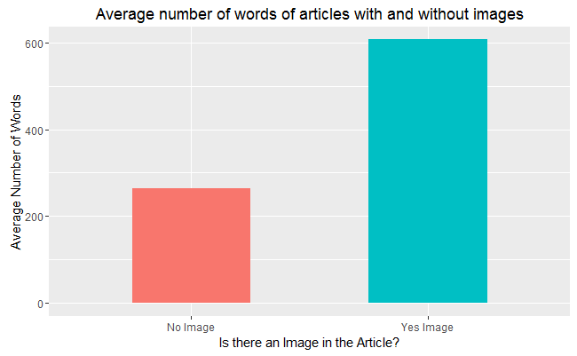

```r
#This plot shows the average number of words in articles with and without images respectively
res1 <- aggregate(number_of_words ~ image_there, data = Q2_data, FUN = mean)
ggplot(data = res1, aes(x = image_there, y = number_of_words)) +
  geom_bar(aes(fill = image_there),stat="identity", width = 0.5) +
  xlab("Is there an Image in the Article?")+ ylab("Average Number of Words") +
  ggtitle("Average number of words of articles with and without images")+
  theme(legend.position = "none")
```

**Description:**This plot shows the average number of words in articles with and without images respectively. We can interpret from this graph that the average number of words in an article with NO IMAGES is much lower than the articles with IMAGES

#### **Q3. Does the rate of sharing positive and negative news vary with the time of the year?**

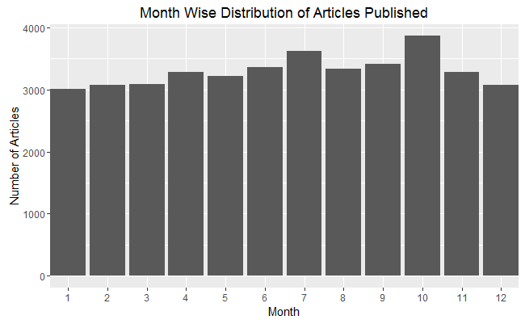

```r
library(ggplot2)
library(xkcd)
OriginalData=read.csv("OnlineNewsPopularity-R.csv")
NewData <- OriginalData[c(2,3,48:51,62)] #create a subset of the data to be used for Q3
pos_news<-ifelse(NewData$global_rate_positive_words>=0.08,1,0) #news with more than 8% of the total words being pos. is considered pos. news, other methods can also be conisdered
NewData$mpos <- pos_news #add new pos. news column to subset
library(dplyr)#library to use filter function
fil = filter(NewData,mpos==1)#filter only pos. news rows
neg_news<-ifelse(NewData$global_rate_negative_words>=0.04,1,0) #news with more than 4% of the total words being neg. is considered neg. news, other methods can also be conisdered
NewData$mneg <- neg_news
filn = filter(NewData,mneg==1)
#R plots for Q3. Does the rate of sharing positive and negative news vary with the time of the year?
vignette("xkcd-intro")
qplot(month, data = NewData, geom = "bar",main = "Month Wise Distribution of Articles Published",xlab = "Month",ylab = "Number of Articles")+scale_x_discrete(limits=c("1", "2","3","4","5","6","7","8","9","10","11","12"))#monthwise distriution
```

**Description:**This plot shows the number of articles published, month by month.From the plot we can see that the most number of articles are published in october. This plot can be used as secondary/support plot to see how does rate of sharing of either positive or negative news vary with the number of articles published in a particular month.

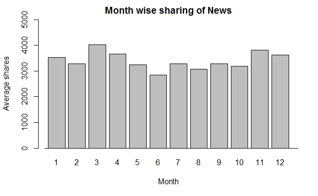

```r
#overall news
#tapply(NewData$shares,NewData$month,mean)
barplot(tapply(NewData$shares,NewData$month,mean),ylim = c(0,5000),main = "Month wise sharing of News",xlab = "Month",ylab = "Average shares")
axis(1, at=c(0,18), labels=c("",""), lwd.ticks=0)#This bar plot shows the month wise mean number of shares. We can use this to see how different rate of sharing of positive and negative news is from the general mean.
```

**Description:**This plot shows the number of average number of shares, month by month. We can see from the plot that the months of March and November have a value of average number of shares as compared to other months. If we compare this plot to the month wise distribtion of articles published, we see that even though more articles were published in the month of October, the average number of shares is not the highest for Octoer. This implies that publishing more articles does not necessarily mean more shares.

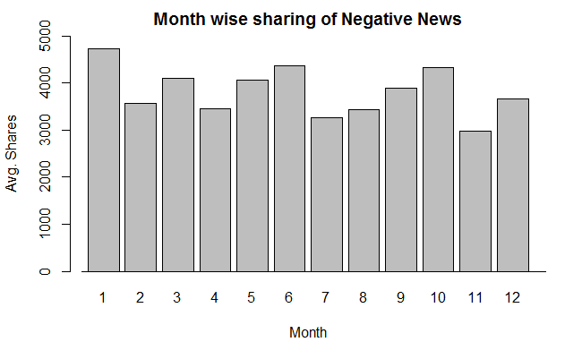

```r
#negative news
#tapply(filn$shares,filn$month,mean)
barplot(tapply(filn$shares,filn$month,mean),ylim = c(0,5000),main = "Month wise sharing of Negative News",xlab = "Month",ylab = "Avg. Shares")
axis(1, at=c(0,18), labels=c("",""), lwd.ticks=0)#using this plot we can identify the months where negative news is shared maximum and minimum
```

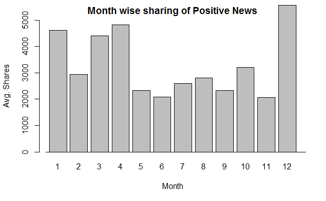

```r
#positive news
#tapply(fil$shares,fil$month,mean)
barplot(tapply(fil$shares,fil$month,mean),ylim = c(0,5000),main = "Month wise sharing of Positive News",xlab = "Month",ylab = "Avg. Shares")
axis(1, at=c(0,18), labels=c("",""), lwd.ticks=0)#using this plot we can identify the months where positive news is shared maximum and minimum
```

**Description:**Similar to the previous plot, this plot shows the month wise average number of shares, but only for **positive news**. We can see from the plot above that average number of shares for positive news is maximum in the Month of December,followed closely by April. The high value in December was an expected result as it is the holiday season.

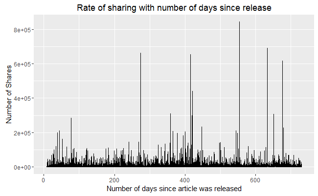

```r
qplot(OriginalData$timedelta,OriginalData$shares,geom="line",main = "Rate of sharing with number of days since release" ,xlab = "Number of days since article was released",ylab = "Number of Shares")#This plot shows how the number of shares for a particular article vary with the time since which it has been released.
```

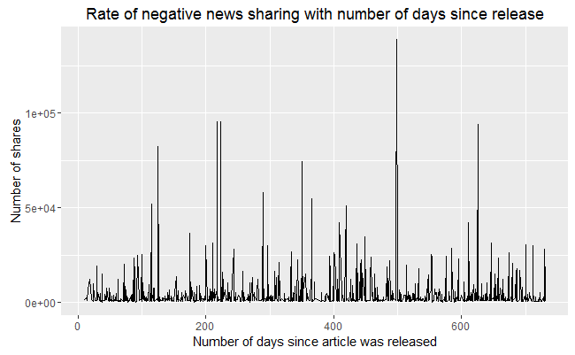

```r
qplot(filn$timedelta,filn$shares,geom="line",main = "Rate of negative news sharing with number of days since release", xlab = "Number of days since article was released",ylab = "Number of shares")#This plot shows how the number of shares for a particular article vary with the time since which it has been released. We can see articles which have been online for 260-450 days have the max. number of shares
```

**Description:** This plot shows the how does the number of shares for negative news vary with the age of the article on the website. As we can see from the plot above, there is no particular trend to the data. However, we can clearly see that the number of shares is less for articles less than 50 days old. This implies that the popularity of an article cannot be decided as soon as the article releases. Some time is needed before the number of shares becomes stagnant.

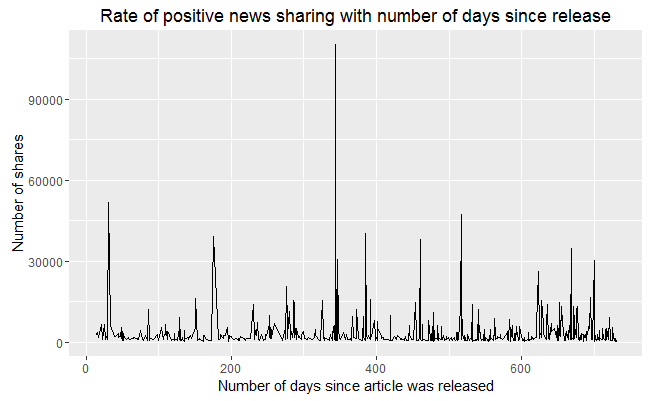

```r
qplot(fil$timedelta,fil$shares,geom="line",main = "Rate of positive news sharing with number of days since release",xlab = "Number of days since article was released",ylab = "Number of shares")#This plot shows how the number of shares for a particular article vary with the time since which it has been released
```

**Description:**Similar to the plot above, this plot shows how does the number of shares for positive news vary with the age of the article. When we compare the plots for positive and negative news, we see that in general, negative news has more number of shares as compared to positive news.